# Homework 11

Shushi Meng

## Question 1: Implementing K-means

### (a) One iteration

I used NumPy default_rng with seed 432 to generate 10 independent pairs of standard normal values. Initial assignment seeds were 11 (run A) and 22 (run B). Each start assigns random labels and then assigns K randomly selected distinct observations to different clusters, so every cluster starts nonempty. Labels in the tables are 1 and 2; Python uses 0 and 1 internally.

| ID | x1 | x2 | Initial A | After one step | Final A | Initial B | Final B |
| --- | --- | --- | --- | --- | --- | --- | --- |
| 1 | 0.7079 | -1.2979 | 1 | 2 | 2 | 2 | 1 |
| 2 | -1.3519 | -0.0643 | 1 | 1 | 1 | 2 | 2 |
| 3 | 0.0859 | -0.5826 | 2 | 2 | 2 | 2 | 1 |
| 4 | -1.1146 | 0.2382 | 1 | 1 | 1 | 1 | 2 |
| 5 | -0.4860 | 1.8064 | 2 | 1 | 1 | 2 | 2 |
| 6 | -0.5342 | -1.9882 | 2 | 2 | 2 | 1 | 1 |
| 7 | 2.1271 | -0.9508 | 2 | 2 | 2 | 1 | 1 |
| 8 | -0.8120 | 0.3576 | 1 | 1 | 1 | 2 | 2 |
| 9 | 0.2784 | 0.7783 | 1 | 1 | 1 | 1 | 2 |
| 10 | 0.7252 | -1.7597 | 2 | 2 | 2 | 1 | 1 |

| Cluster | Initial mean x1 | Initial mean x2 |
| --- | --- | --- |
| 1 | -0.4585 | 0.0024 |
| 2 | 0.3836 | -0.6950 |

These means are calculated from the initial assignments in run A. I assigned each point to the nearest mean using squared Euclidean distance, which gives the same choice as Euclidean distance. The updated assignments are in the “After one step” column. The left plot below shows this step; crosses mark the means used for assignment.

### (b) K-means function

The function below works for any number of columns. Each cycle assigns points to the current means and then recalculates the means. The initial means are calculated before the loop, so this is the same sequence as repeatedly calculating means and assigning points. An empty cluster retains its last mean. Exact distance ties go to the lowest cluster index. Means are recalculated before every return, including when the iteration limit is reached; reaching that limit need not give a converged solution.

```
import numpy as np

def kmeans(X, K, initial, max_iter=300):
    X = np.asarray(X, dtype=float)
    labels = np.asarray(initial, dtype=int).copy()
    if X.ndim != 2 or not np.isfinite(X).all():
        raise ValueError('X must be a finite data matrix')
    if not 1 <= K <= len(X) or max_iter < 1:
        raise ValueError('Invalid K or iteration limit')
    if labels.shape != (len(X),) or set(labels) != set(range(K)):
        raise ValueError('Initial labels must contain every cluster')
    centers = np.array([X[labels == k].mean(axis=0) for k in range(K)])
    history = []
    converged = False
    for iteration in range(1, max_iter + 1):
        distances = ((X[:, None, :] - centers[None, :, :]) ** 2).sum(axis=2)
        updated = distances.argmin(axis=1)  # First center wins exact ties.
        converged = np.array_equal(updated, labels)
        labels = updated
        for k in range(K):
            if np.any(labels == k):
                centers[k] = X[labels == k].mean(axis=0)
            # An empty cluster keeps its previous center.
        wcss = float(((X - centers[labels]) ** 2).sum())
        history.append(wcss)
        if converged:
            break
    return dict(labels=labels, centers=centers, wcss=wcss,
                iterations=iteration, converged=converged, history=history)
```

Assigning each point to a nearest center cannot increase WCSS. For fixed assignments, the sample mean minimizes the sum of squared distances within each nonempty cluster. Therefore, each complete cycle cannot increase WCSS. This explains the descent property, but it does not establish a global minimum.

### (c) Two initial assignments

| Run | Cluster | Mean x1 | Mean x2 | Total WCSS | Cycles |
| --- | --- | --- | --- | --- | --- |
| A | 1 | -0.6972 | 0.6232 | 8.9557 | 2 |
| A | 2 | 0.6224 | -1.3158 | 8.9557 | 2 |
| B | 1 | 0.6224 | -1.3158 | 8.9557 | 2 |
| B | 2 | -0.6972 | 0.6232 | 8.9557 | 2 |

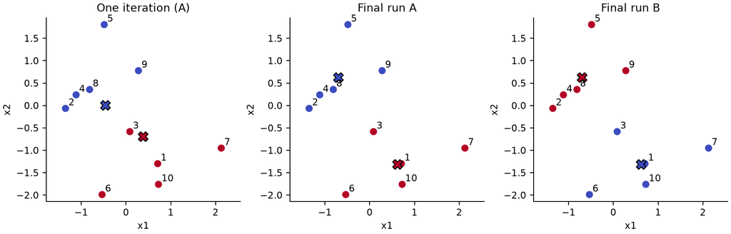

Both starts converged after two cycles to the same grouping (with cluster labels swapped) and WCSS, 8.955689. I also checked all 511 distinct nonempty two-way partitions, treating swapped cluster labels as the same partition. Their minimum WCSS was 8.955689, confirming the global minimum for this small dataset. Different starts need not agree on another dataset.

## Question 2: Image color compression

### (a) Image and pixel matrix

I selected the Grace Hopper color portrait included in Matplotlib’s sample data (grace_hopper.jpg). The source is 512 × 600 pixels (width × height). I resized it with Lanczos resampling, preserving its aspect ratio, to 171 × 200 pixels. The first panel below is the resized original. The RGB array has shape (200, 171, 3); reshaping it gives a 34,200 × 3 pixel matrix. Every channel is divided by 255, so all fits use RGB values on [0, 1], without separate channel standardization.

```
image = Image.open('data/grace_hopper.jpg').convert('RGB')
image.thumbnail((200, 200), Image.Resampling.LANCZOS)
rgb = np.asarray(image, dtype=float) / 255
pixels = rgb.reshape(-1, 3)
# For each K, try nonempty starts with seeds 432, 433, 434.
fits = [kmeans(pixels, K, initial_labels(len(pixels), K, s))
        for s in (432, 433, 434)]
fit = min(fits, key=lambda f: f['wcss'])
compressed = fit['centers'][fit['labels']].reshape(rgb.shape)
```

### (b) Compressed images and centers

For each K, I retained the smallest WCSS from three random starts, with a maximum of 300 cycles each. All 12 fits stopped because assignments stopped changing. The summary reports the selected start; WCSS uses all 34,200 pixels and unrounded centers. Center labels only identify colors within each fit.

| K | Seed | Cycles | WCSS |
| --- | --- | --- | --- |
| 2 | 432 | 8 | 2451.144 |
| 3 | 432 | 20 | 1422.966 |
| 5 | 432 | 23 | 590.796 |
| 10 | 432 | 90 | 298.308 |

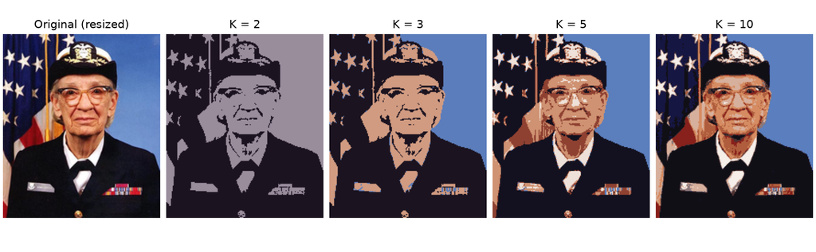

| K | Color | Red | Green | Blue |
| --- | --- | --- | --- | --- |
| 2 | 1 | 0.6003 | 0.5534 | 0.6150 |
| 2 | 2 | 0.1086 | 0.0753 | 0.1250 |
| 3 | 1 | 0.1093 | 0.0758 | 0.1251 |
| 3 | 2 | 0.3595 | 0.4918 | 0.7342 |
| 3 | 3 | 0.8201 | 0.6101 | 0.5082 |
| 5 | 1 | 0.5617 | 0.2563 | 0.1953 |
| 5 | 2 | 0.3582 | 0.4949 | 0.7423 |
| 5 | 3 | 0.9366 | 0.8842 | 0.8511 |
| 5 | 4 | 0.0777 | 0.0677 | 0.1235 |
| 5 | 5 | 0.8153 | 0.5760 | 0.4484 |
| 10 | 1 | 0.6887 | 0.3686 | 0.2419 |
| 10 | 2 | 0.0679 | 0.0594 | 0.0874 |
| 10 | 3 | 0.8448 | 0.6911 | 0.6163 |
| 10 | 4 | 0.5413 | 0.4684 | 0.4833 |
| 10 | 5 | 0.9618 | 0.9370 | 0.9154 |
| 10 | 6 | 0.3543 | 0.4962 | 0.7485 |
| 10 | 7 | 0.0878 | 0.0875 | 0.2632 |
| 10 | 8 | 0.5372 | 0.1275 | 0.1084 |
| 10 | 9 | 0.3051 | 0.1943 | 0.1917 |
| 10 | 10 | 0.8407 | 0.5524 | 0.3860 |

## Question 3: Hierarchical clustering of cars

### (a) Standardization and linkage comparison

I used all 32 cars and 11 numerical columns, excluding car names from the variables. There were no missing values. For each variable, z = (x − sample mean) / sample standard deviation, using denominator n − 1. I then calculated Euclidean distances between rows and used single, complete, and average linkage.

```
cars = pd.read_csv('data/mtcars.csv').set_index('car')
Z = (cars - cars.mean()) / cars.std(ddof=1)
trees = {method: linkage(pdist(Z), method=method)
         for method in ('single', 'complete', 'average')}
groups = fcluster(trees['complete'], 3, criterion='maxclust')
means = cars.groupby(groups).mean()
```

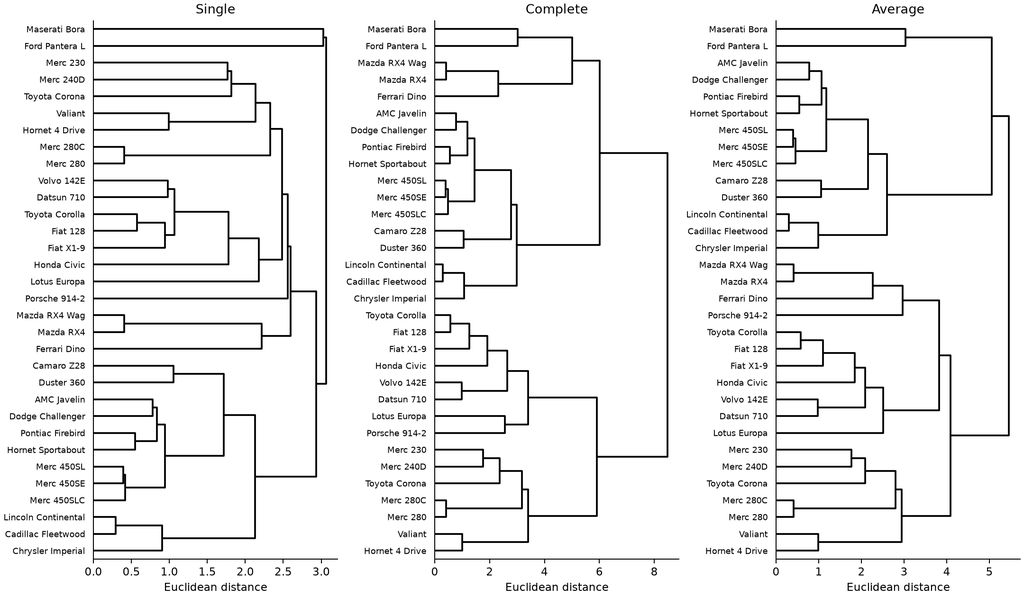

Single linkage joins clusters using their closest pair. Its tree has many small late additions, showing the chaining effect. Complete linkage uses the farthest pair and gives more compact groups; average linkage uses the mean pairwise distance and gives an intermediate pattern. All three join the Mazda RX4 pair and the Merc 450 models early, but their larger branches differ. For example, average linkage leaves Ford Pantera L and Maserati Bora as a separate pair until near the final merge. The distance axes differ because the linkage definitions differ.

### (b) Three complete-linkage groups

I chose complete linkage with three clusters. A cut at height 5.95 gives these groups: the next two merges occur at 6.018 and 8.480. The previous merge is at 5.905, so the gap supporting exactly three groups is small. Two groups have a clearer final separation, but three give a useful distinction between large automatic cars and the smaller manual performance group. This is an interpretable choice rather than a uniquely determined number of clusters.

Cluster 1 (15 cars): Datsun 710, Hornet 4 Drive, Valiant, Merc 240D, Merc 230, Merc 280, Merc 280C, Fiat 128, Honda Civic, Toyota Corolla, Toyota Corona, Fiat X1-9, Porsche 914-2, Lotus Europa, Volvo 142E.

Cluster 2 (12 cars): Hornet Sportabout, Duster 360, Merc 450SE, Merc 450SL, Merc 450SLC, Cadillac Fleetwood, Lincoln Continental, Chrysler Imperial, Dodge Challenger, AMC Javelin, Camaro Z28, Pontiac Firebird.

Cluster 3 (5 cars): Mazda RX4, Mazda RX4 Wag, Ford Pantera L, Ferrari Dino, Maserati Bora.

Cluster means below use the original units. The table is split for readability; it includes every numerical variable.

| Cluster | n | mpg | cyl | disp | hp | drat | wt |
| --- | --- | --- | --- | --- | --- | --- | --- |
| 1 | 15 | 24.65 | 4.53 | 131.65 | 91.33 | 3.90 | 2.58 |
| 2 | 12 | 15.05 | 8.00 | 357.62 | 194.17 | 3.12 | 4.10 |
| 3 | 5 | 18.50 | 6.80 | 223.40 | 198.80 | 3.84 | 3.00 |

| Cluster | qsec | vs | am | gear | carb |
| --- | --- | --- | --- | --- | --- |
| 1 | 19.16 | 0.93 | 0.53 | 3.93 | 1.80 |
| 2 | 17.14 | 0.00 | 0.00 | 3.00 | 3.08 |
| 3 | 15.62 | 0.00 | 1.00 | 4.60 | 5.20 |

Cluster 1 contains mostly smaller, more economical cars: mean mpg is 24.65, weight is 2.58 thousand pounds, and horsepower is 91.33. Cluster 2 consists of eight-cylinder automatic cars, with the largest mean displacement (357.62 cubic inches), greatest mean weight (4.10 thousand pounds), and lowest fuel economy (15.05 mpg). Cluster 3 contains five manual cars, including the two Mazdas and three performance models. It has high average horsepower (198.80), more gears (4.60), and the shortest mean quarter-mile time (15.62 seconds). These are descriptive patterns, not strict categories for every car.

Standardization matters because raw displacement and horsepower have much larger numerical spreads than binary variables or weight. Without scaling, they would dominate Euclidean distance largely because of their units. Standardization gives each variable unit variance, although correlated variables can still give repeated emphasis to related features. The means of vs and am are proportions; the assignment treats these binary columns as numerical variables as instructed.

## Calculation checks

I independently recomputed WCSS from point-to-center differences and verified final means and nearest-center assignments for both small-data fits and all 12 image fits. WCSS was nonincreasing in every recorded run. Additional checks covered an empty cluster, K = 1, one-variable input, and stopping after one cycle. For the cars, standardized column means and sample standard deviations were checked against 0 and 1, and a separate direct complete-linkage implementation reproduced every merge height. These checks support the reported calculations; only the small two-cluster example was checked exhaustively for a global optimum.